# PA1_template

Ingrieta

21/4/2021

## 1. Loading and preprocessing the data

```r
if (!file.exists("activity.csv") ) #si no existe el archivo cargalo y descomprimirlo
    {
     url <- 'http://d396qusza40orc.cloudfront.net/repdata%2Fdata%2Factivity.zip'
     download.file(url,destfile='repdata%2Fdata%2Factivity.zip',mode='wb')
     unzip('repdata%2Fdata%2Factivity.zip')
    }
df_activity <-read.csv("activity/activity.csv")
```

## What is mean total number of steps taken per day?

### 1. Make a histogram of the total number of steps taken each day

```r
library(dplyr)
library(lubridate)
Sys.setlocale("LC_TIME") #porque la fecha esta en local Mexico
```

```
## [1] "Spanish_Mexico.1252"
```

```r
df_activity$date <- as.Date(df_activity$date, format = "%Y-%m-%d")

df_steps_per_day <- df_activity%>%select(date,steps)%>%group_by(date)%>%summarise('steps per day'=sum(steps),'media' = mean(steps))
```

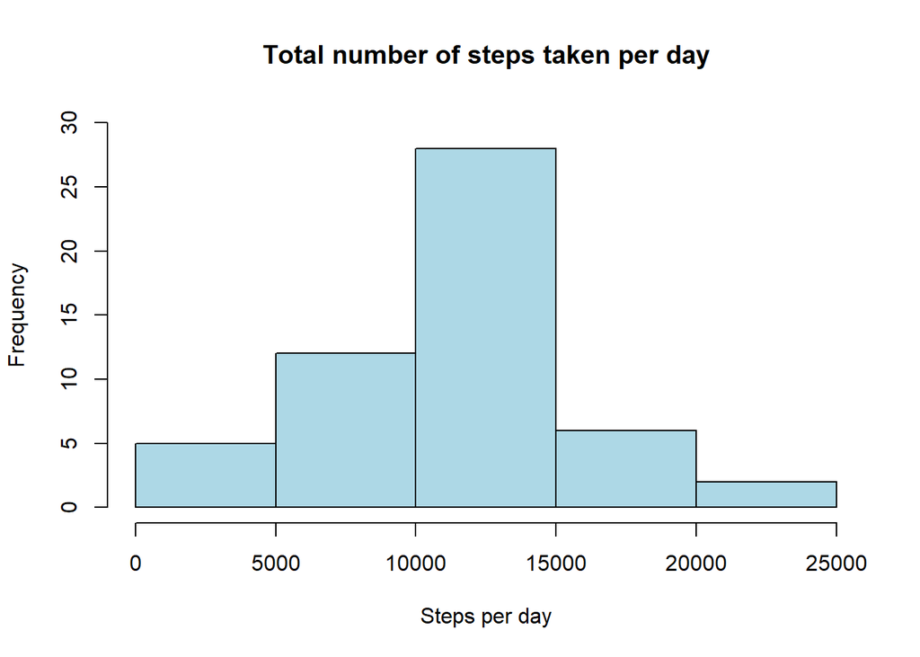

```r
hist(df_steps_per_day$`steps per day`,main = "Total number of steps taken per day", xlab= "Steps per day", col = "lightblue", ylim = c(0,30))
```

```r
dev.copy(png,"plot1.png", width=480, height=480)
```

```r
dev.off()
```

```r
steps_mean<-mean(df_steps_per_day$`steps per day`,na.rm = T)
steps_median <-median(df_steps_per_day$`steps per day`,na.rm = T)
```

## What is the average daily activity pattern?

1. Make a time series plot (i.e. type = “l”) of the 5-minute interval (x-axis) and the average number of steps taken, averaged across all days (y-axis)

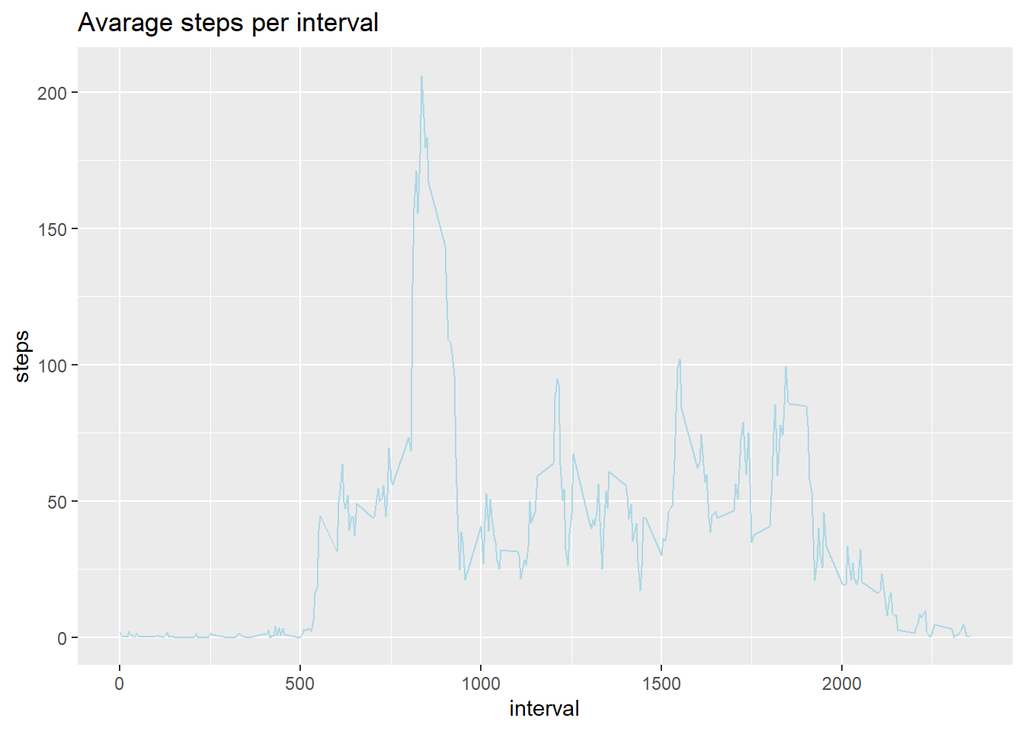

```r
df_steps_interval <- aggregate(steps ~ interval, df_activity, mean)

library(ggplot2)
g1 = ggplot(data = df_steps_interval, aes(x= interval, y = steps))+geom_line(col= "lightblue") + labs(title="Avarage steps per interval")
print(g1)
```

```r
ggsave("Plot2.png", width = 20, height = 20, units = "cm")
```

2.Which 5-minute interval, on average across all the days in the dataset, contains the maximum number of steps?

```r
max_steps_interval <- df_steps_interval[which.max(df_steps_interval$steps),1]
```

835 interval has the maximum number of steps.

## Imputing missing values

1. Calculate and report the total number of missing values in the dataset (i.e. the total number of rows with NAs)

```r
v_nas <- is.na(df_activity) #vector T y F
total_nas <- sum(v_nas)  #los T los suma como 1
```

Total NA´s equal to 2304.

2. Devise a strategy for filling in all of the missing values in the dataset. The strategy does not need to be sophisticated. For example, you could use the mean/median for that day, or the mean for that 5-minute interval, etc.

```r
na_index <-  which(is.na(df_activity$steps)) # tengo los indices que tienen NAs en steps
#sustituir NAs con la media del intervalo
df_missing <- left_join(df_activity[na_index, ],df_steps_interval, by = "interval")
df_complete <-df_activity
```

3. Create a new dataset that is equal to the original dataset but with the missing data filled in.

```r
df_complete[na_index,"steps"]<- df_missing[,"steps.y"]
```

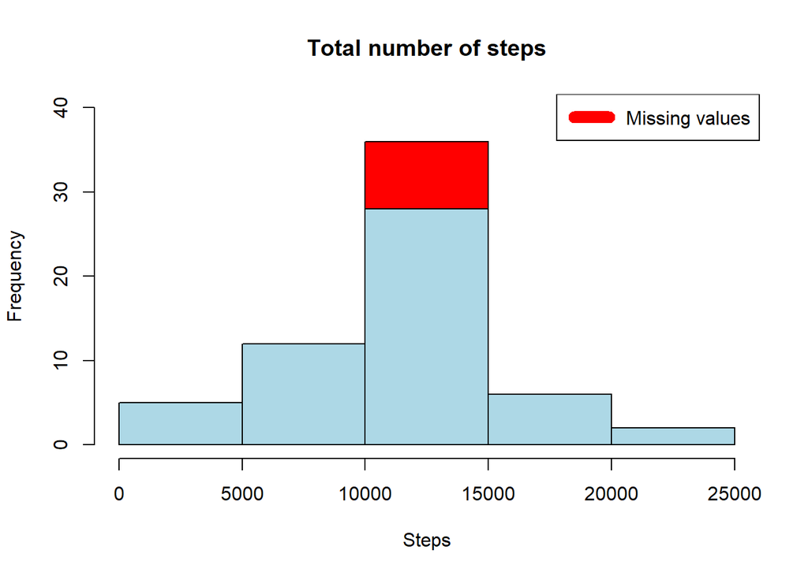

```r
df_steps_per_day_nas <-aggregate(steps ~ date, df_complete, sum)
hist(df_steps_per_day_nas$steps, main = "Total number of steps", xlab= "Steps", col = "red", ylim = c(0,40))
hist(df_steps_per_day$`steps per day`,main = "Total number of steps with NAs", xlab= "Steps", col = "lightblue", ylim = c(0,40), add=T)
legend("topright", c("Missing values"), col=c("red"), lwd=10)
```

```r
dev.copy(png,"plot3.png", width=480, height=480)
```

```r
dev.off()
```

## Are there differences in activity patterns between weekdays and weekends?

1.Create a new factor variable in the dataset with two levels – “weekday” and “weekend” indicating whether a given date is a weekday or weekend day.

```r
Sys.setlocale("LC_TIME", "English")
```

```
## [1] "English_United States.1252"
```

```r
weekday<- weekdays(df_activity$date)
df_activity<-cbind(df_activity, weekday)
weekend <- c("Saturday", "Sunday")
df_activity$day[(df_activity$weekday %in% weekend)]<- ("weekend")
df_activity$day[(!df_activity$weekday %in% weekend)]<- ("weekday")
df_activity$day<-as.factor(df_activity$day)
df_activity_weekday<- aggregate(steps~interval+day, df_activity,mean, na.rm =TRUE)
```

2. Make a panel plot containing a time series plot (i.e. type = “l”) of the 5-minute interval (x-axis) and the average number of steps taken, averaged across all weekday days or weekend days (y-axis). The plot should look something like the following, which was created using simulated data:

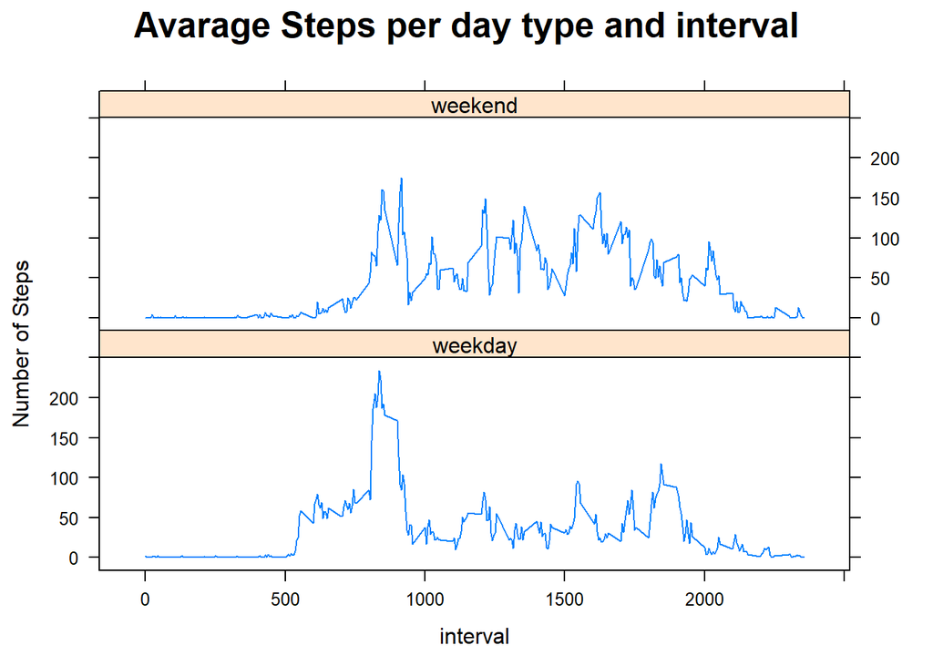

```r
library(lattice)
xyplot(steps ~  interval | day, data = df_activity_weekday, layout = c(1,2), type ="l", ylab="Number of Steps", main=list("Avarage Steps per day type and interval", cex=1.6))
```

```r
dev.copy(png,"plot4.png", width=480, height=480)
```

```r
dev.off()
```